# virilis_group_intra-inter_species

Jullien Flynn

2019-03-19

This script goes through the analysis of simple satellites across multiple strains of the three D. virilis group species we are studying.

## Load in data (from k-seek) and do basic processing

```r
# bring in the depth file (depth was calculated as the amount of bp sequenced in all reads divided by the expected genome size from Bosco et al. 2007)

samples_depth <- read.csv ('/Users/jullienflynn/Documents/AndyLab/Heterochromatin/PacBio_scripts/Revised_scripts/D_virilis_satellites/Intra_inter_species_sequencing/ForR/samples_depth.csv')

sample_names <- samples_depth$Sample
samples_depth[,1] <- NULL
rownames(samples_depth) <- sample_names

#now bring in the compiled data.

data2 <- read.delim ('/Users/jullienflynn/Documents/AndyLab/Heterochromatin/PacBio_scripts/Revised_scripts/D_virilis_satellites/Intra_inter_species_sequencing/ForR/Dvir_diversity.rep.compiled')

kmer.labels <- sapply(strsplit(colnames(data2), "\\."), '[', 1)
colnames(data2) <- kmer.labels
samples <- as.vector(data2$lines)
samples2 <- sapply(strsplit(samples, "[.]"), '[', 1)
#samples2
data2[,1] <- NULL
rownames(data2) <- samples2

# put the depths in the same order as the dataframe
data2_ordered <- data2[ order(row.names(data2)), ]

samples_depth_ordered <- samples_depth[ order(row.names(samples_depth)), ]

# now normalize the data
data2_normalized <- data2_ordered/samples_depth_ordered

# now sort the data
kmer_means <- colMeans(data2)
data2_normalized_sorted <- data2_normalized[,order(kmer_means, decreasing=T)]

# now bring in the sample identities

sample_identities <- read.table ('/Users/jullienflynn/Documents/AndyLab/Heterochromatin/PacBio_scripts/Revised_scripts/D_virilis_satellites/Intra_inter_species_sequencing/ForR/sample.identities', header=F)

sample_names <- sample_identities$V1
sample_identities$V1 <- NULL
colnames(sample_identities) <- "species"
rownames(sample_identities) <- sample_names

# merge in the species identities so we can easily categorize them
data_classified <- merge (sample_identities, data2_normalized_sorted, by=0)

sample.labels <- sapply(strsplit(data_classified$Row.names, "_"), '[', 1)
data_classified$Row.names <- sample.labels
data_classified[,1:5]
```

```
##    Row.names species total_bp AAACTAC      AAACTAT
## 1   amCI0515    amer 18453848 1665681   63820.2381
## 2   amCI0518    amer 17011377 1491108   55388.5949
## 3   amCI0538    amer 21755806 2163297   29607.3799
## 4      amG96    amer 14613866 1219332    4252.1640
## 5   amMK1012    amer 18815286 1760862   33670.0087
## 6   amML0738    amer 19727841 1783893   25970.1261
## 7    amML975    amer 16431951 1402413   24170.6987
## 8       amSB    amer 17393730 1582941   34958.2070
## 9       Dvir     vir 26859465 1510560 1188953.9369
## 10   Gnova14    nova 11843275  908856    3442.0582
## 11   Gvir87f     vir 38957129 2465773 1586577.3192
## 12    nova12    nova 15927381 1448441    2299.9194
## 13    nova13    nova 13323668 1002546     825.1303
## 14     nova4    nova 13356324 1049831    1891.6012
## 15     nova8    nova 14267697 1124533    1763.8906
## 16     vir00     vir 83163214 5864376 3269728.3703
## 17     vir08     vir 68035891 3910827 2975041.6229
## 18    vir118     vir 67465886 4533416 2710163.3013
## 19     vir47     vir 70245982 4726444 2401100.1770
## 20     vir48     vir 80264321 4944936 3464648.7619
## 21     vir49     vir 62696813 4290555 2206843.5696
## 22     vir51     vir 76244550 5004988 3325663.4179
## 23     vir52     vir 65136197 3855960 2995056.2475
## 24     vir85     vir 71417588 4516385 2892893.8759
## 25     vir86     vir 74352552 4655635 3255046.5862
## 26      vir9     vir 80570614 5135902 3082091.8466
```

# 1) Look at variation among AAACTAC amount and total bp of simple satellites across species

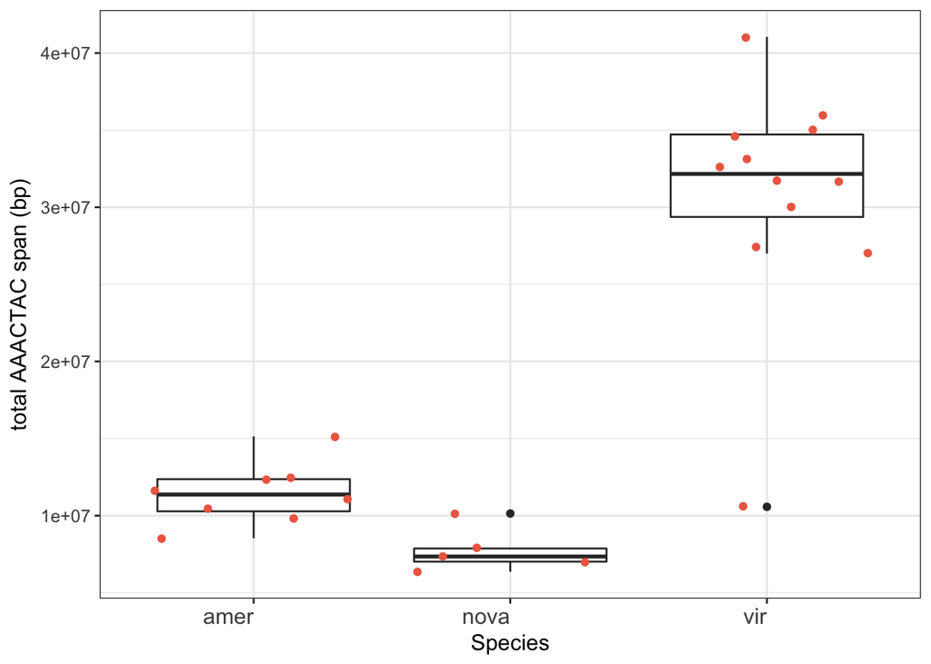

```r
library(ggplot2)
data_classified <- data_classified[-11,]

ggplot(data = data_classified, aes(x = species, y = AAACTAC*7)) +
  geom_boxplot() +
  geom_jitter(color="coral2") +
  theme_bw() +
  xlab("Species") +
  ylab("total AAACTAC span (bp)") +
  theme(axis.text.x = element_text(hjust = 1, size=12)) +
  theme(text = element_text(size=12))
```

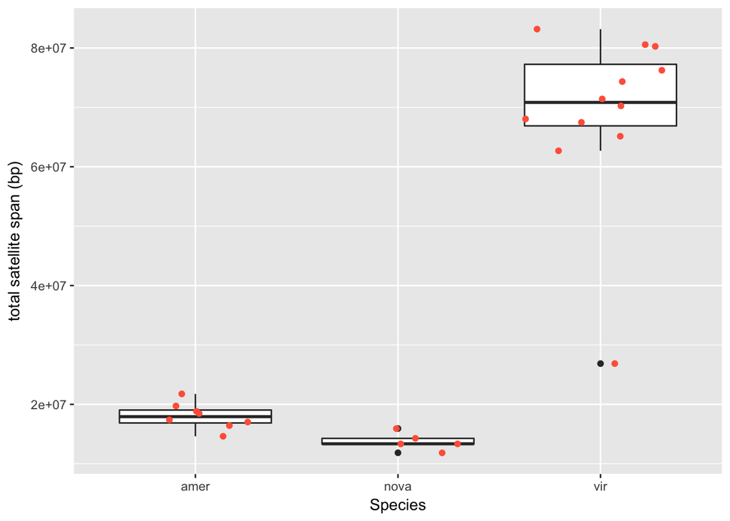

```r
ggplot(data = data_classified, aes(x = species, y = total_bp)) +
  geom_boxplot() +
  geom_jitter(color="tomato") +
  xlab("Species") +
  ylab("total satellite span (bp)")
```

# 2) Produce PCAs with the 4 main satellites (AAACTAC, AAACTAT, AAATTAC, AAACAAC) and the top 20 most abundant satellites

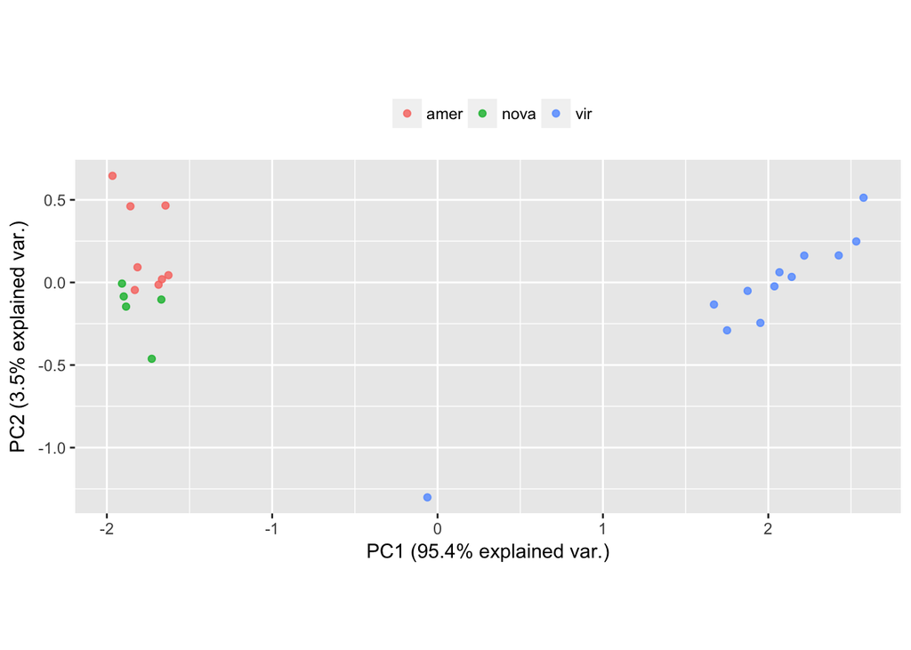

```r
kmers_of_interest <- c("AAACTAC", "AAACTAT", "AAATTAC", "AAACAAC")

pca.data <- prcomp(data_classified[, kmers_of_interest], scale.=T)
library(ggbiplot)
g <- ggbiplot(pca.data, obs.scale = 1, var.scale = 1, groups = data_classified$species, var.axes = F, alpha=0.8) #labels=data3$Row.names
g <- g + scale_color_discrete(name='')
g <- g + theme(legend.direction='horizontal', legend.position='top')
print(g)
```

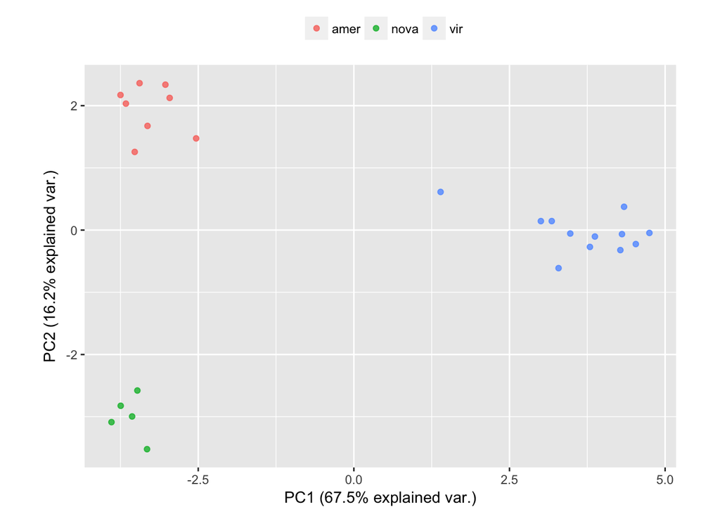

```r
# let's use the whole dataset and see how the PCA looks
pca.data <- prcomp(data_classified[,3:22], scale.=T)
g <- ggbiplot(pca.data, obs.scale = 1, var.scale = 1, groups = data_classified$species, var.axes = F, alpha=0.8)
g <- g + scale_color_discrete(name='')
g <- g + theme(legend.direction='horizontal', legend.position='top')
print(g)
```

# 3) Now, let’s take a closer look at the abundance of satellites in the D. virilis samples.

```r
data_virilis <- subset(data_classified, species=="vir")
vir_names <- data_virilis$Row.names
rownames(data_virilis) <- vir_names
data_virilis[,kmers_of_interest]*7
```

```
##         AAACTAC  AAACTAT  AAATTAC   AAACAAC
## Dvir   10573923  8322678  4881368  8940.322
## vir00  41050630 22888099 14290513 31213.229
## vir08  27375791 20825291 14842229 21785.747
## vir118 31733914 18971143 12345316  2682.125
## vir47  33085111 16807701 15900689 25035.208
## vir48  34614554 24252541 14920122 21244.857
## vir49  30033885 15447905 13057228 23911.108
## vir51  35034916 23279644 12424728 20882.889
## vir52  26991723 20965394 12128714 18157.747
## vir85  31614697 20250257 13956118 21278.321
## vir86  32589446 22785326 13128309 21668.535
## vir9   35951315 21574643 17470868 23762.369
```

```r
totals_vir <- rowSums(data_virilis[,kmers_of_interest]*7)

# which sample has the least amount of satellites and which has the most?
totals_vir[which(totals_vir == max(totals_vir))]
```

```
##    vir00
## 78260455
```

```r
totals_vir[which(totals_vir == min(totals_vir))]
```

```
##     Dvir
## 23786909
```

```r
# Get the mean amounts of each satellites.

mean(data_virilis$AAACTAC)
```

```
## [1] 4412499
```

```r
mean(data_virilis$AAACAAC)
```

```
## [1] 2863.839
```

```r
mean(data_virilis$AAACTAT)
```

```
## [1] 2813936
```

```r
mean(data_virilis$AAATTAC)
```

```
## [1] 1896979
```

```r
# bring in the geographical origin
virilis_ori <- read.csv('/Users/jullienflynn/Documents/AndyLab/Heterochromatin/PacBio_scripts/Revised_scripts/D_virilis_satellites/Intra_inter_species_sequencing/ForR/virilis_origins.csv')

virilis_ori[!apply(virilis_ori == "", 1, all),]
```

```
##               Sample        Origin
## 1    vir51_GTGAAA_R1        S.Amer
## 2    vir52_ACTGAT_R1        Russia
## 3    vir86_GAGTGG_R1        C.Amer
## 4    vir47_ATCACG_R1         China
## 5    vir49_GTGGCC_R1        S.Amer
## 6    vir85_GTTTCG_R1         Japan
## 7    vir08_ATTCCT_R1        N.Amer
## 8    vir00_TAGCTT_R1        N.Amer
## 9   vir118_CGTACG_R1        Africa
## 10   vir48_GGCTAC_R1        C.Amer
## 11      Dvir_flies_1 Genome.strain
## 12    vir9_TTAGGC_R1         Japan
## 13 Gvir87f_TAGCTT_R1       Unknown
```

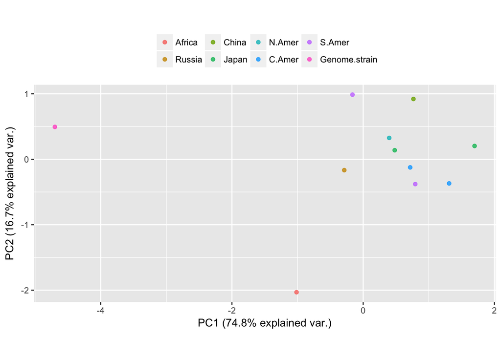

```r
virilis_ori$Sample <- as.vector(virilis_ori$Sample)
sample.labels <- sapply(strsplit(virilis_ori$Sample, "_"), '[', 1)
virilis_ori$Sample <- sample.labels

data_virilis_ori <- merge(data_virilis, virilis_ori, by.x=1, by.y=1)

data_virilis_ori$Origin <- factor(data_virilis_ori$Origin, levels = c("Africa", "Russia", "China", "Japan", "N.Amer", "C.Amer", "S.Amer", "Genome.strain"))


data_virilis_ori <- data_virilis_ori[-2,]
options(scipen=999)

pca.data <- prcomp(data_virilis_ori[, kmers_of_interest], scale.=T)

g <- ggbiplot(pca.data, obs.scale = 1, var.scale = 1, groups = data_virilis_ori$Origin, var.axes = F, alpha=0.8)
g <- g + scale_color_discrete(name='')
g <- g + theme(legend.direction='horizontal', legend.position='top')
print(g)
```

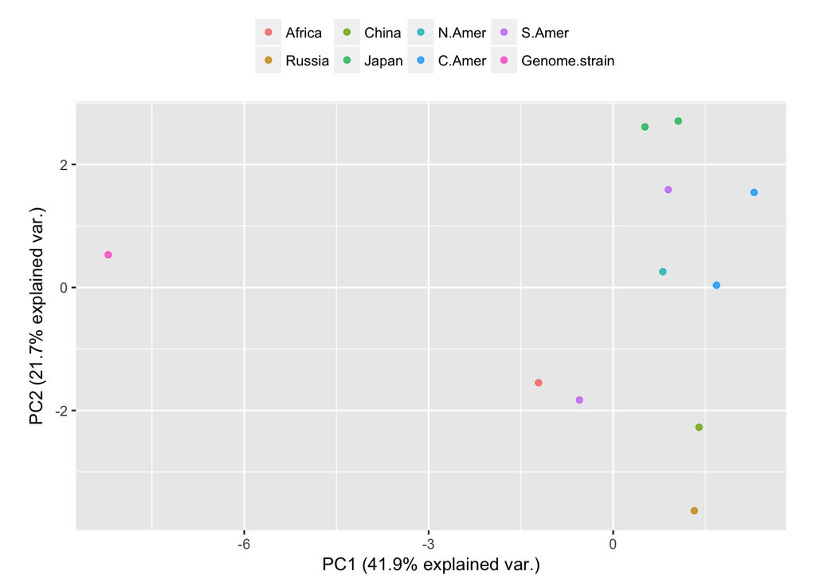

```r
pca.data <- prcomp(data_virilis_ori[, 4:23], scale.=T)

g <- ggbiplot(pca.data, obs.scale = 1, var.scale = 1, groups = data_virilis_ori$Origin, var.axes = F, alpha=0.8)
g <- g + scale_color_discrete(name='')
g <- g + theme(legend.direction='horizontal', legend.position='top')
print(g)
```

```r
# now let's make some plots relating the satellite amount to the geography.


(plot_data <- data_virilis_ori[, c("Row.names", "total_bp", "Origin", "AAACTAC", "AAACTAT", "AAATTAC")])
```

```
##    Row.names total_bp        Origin AAACTAC AAACTAT   AAATTAC
## 1       Dvir 26859465 Genome.strain 1510560 1188954  697338.3
## 3      vir08 68035891        N.Amer 3910827 2975042 2120318.4
## 4     vir118 67465886        Africa 4533416 2710163 1763616.5
## 5      vir47 70245982         China 4726444 2401100 2271527.0
## 6      vir48 80264321        C.Amer 4944936 3464649 2131445.9
## 7      vir49 62696813        S.Amer 4290555 2206844 1865318.2
## 8      vir51 76244550        S.Amer 5004988 3325663 1774961.1
## 9      vir52 65136197        Russia 3855960 2995056 1732673.5
## 10     vir85 71417588         Japan 4516385 2892894 1993731.1
## 11     vir86 74352552        C.Amer 4655635 3255047 1875472.7
## 12      vir9 80570614         Japan 5135902 3082092 2495838.2
```

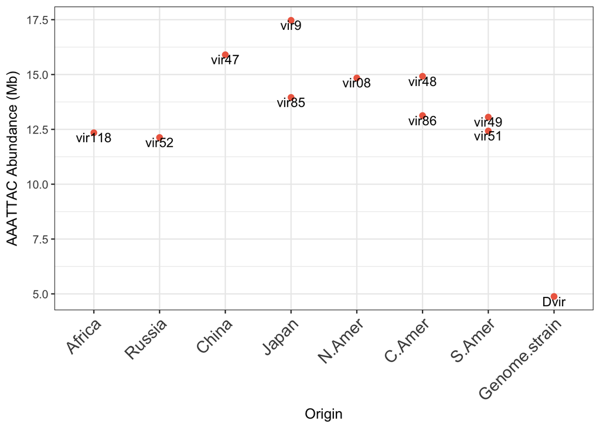

```r
plot_data$total_bp <- plot_data$total_bp/10^6
plot_data$AAACTAC <- plot_data$AAACTAC*7/10^6
plot_data$AAACTAT <- plot_data$AAACTAT*7/10^6
plot_data$AAATTAC <- plot_data$AAATTAC*7/10^6

options(scipen=500)
ggplot(plot_data, aes(y=AAATTAC, x=Origin)) +
  geom_point(size=2, color='coral2') +
  theme_bw() +
  geom_text(aes(label=Row.names),hjust=0.5, vjust=1) +
  ylab("AAATTAC Abundance (Mb)") +
  theme(axis.text.x = element_text(angle = 45, hjust = 1, size=14)) +
  theme(text = element_text(size=12))
```

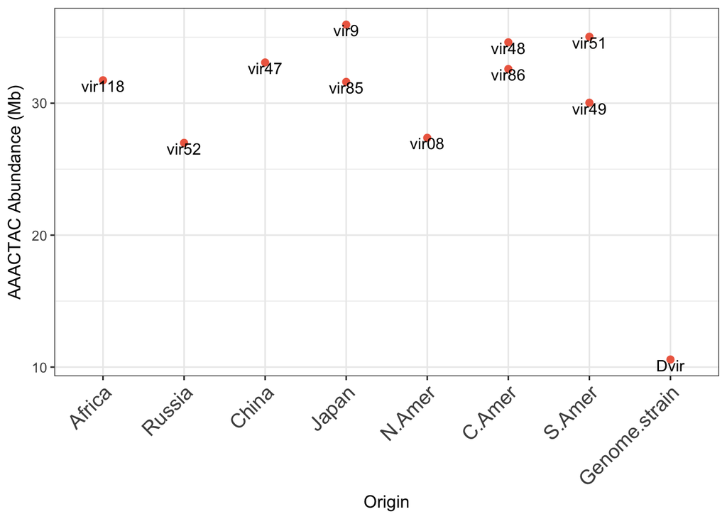

```r
ggplot(plot_data, aes(y=AAACTAC, x=Origin)) +
  geom_point(size=2, color='coral2') +
  theme_bw() +
  geom_text(aes(label=Row.names),hjust=0.5, vjust=1.0) +
  ylab("AAACTAC Abundance (Mb)") +
  theme(axis.text.x = element_text(angle = 45, hjust = 1, size=14)) +
  theme(text = element_text(size=12))
```

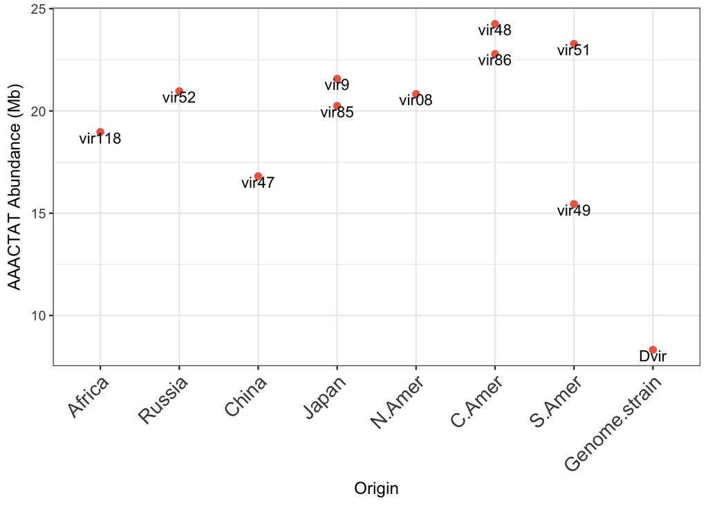

```r
ggplot(plot_data, aes(y=AAACTAT, x=Origin)) +
  geom_point(size=2, color='coral2') +
   theme_bw() +
  geom_text(aes(label=Row.names),hjust=0.5, vjust=1.0) +
  ylab("AAACTAT Abundance (Mb)") +
  theme(axis.text.x = element_text(angle = 45, hjust = 1, size=14)) +
  theme(text = element_text(size=12))
```

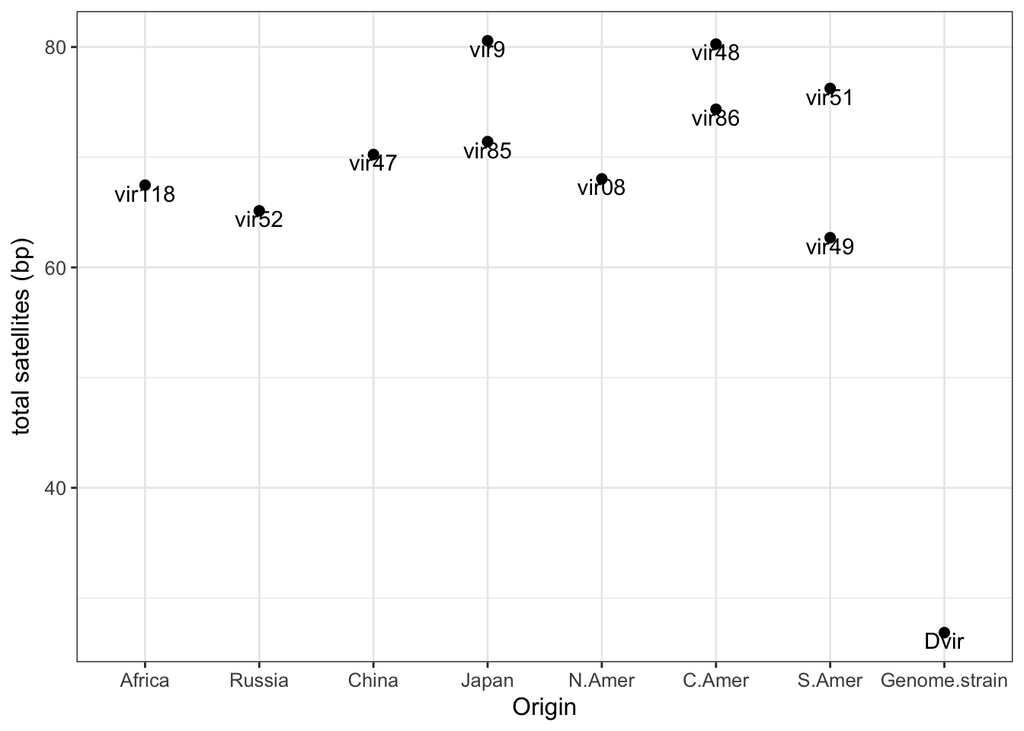

```r
ggplot(plot_data, aes(y=total_bp, x=Origin)) +
  geom_point(size=2) +
   theme_bw() +
  geom_text(aes(label=Row.names),hjust=0.5, vjust=1.0) +
  ylab("total satellites (bp)") +
  theme(text = element_text(size=12))
```

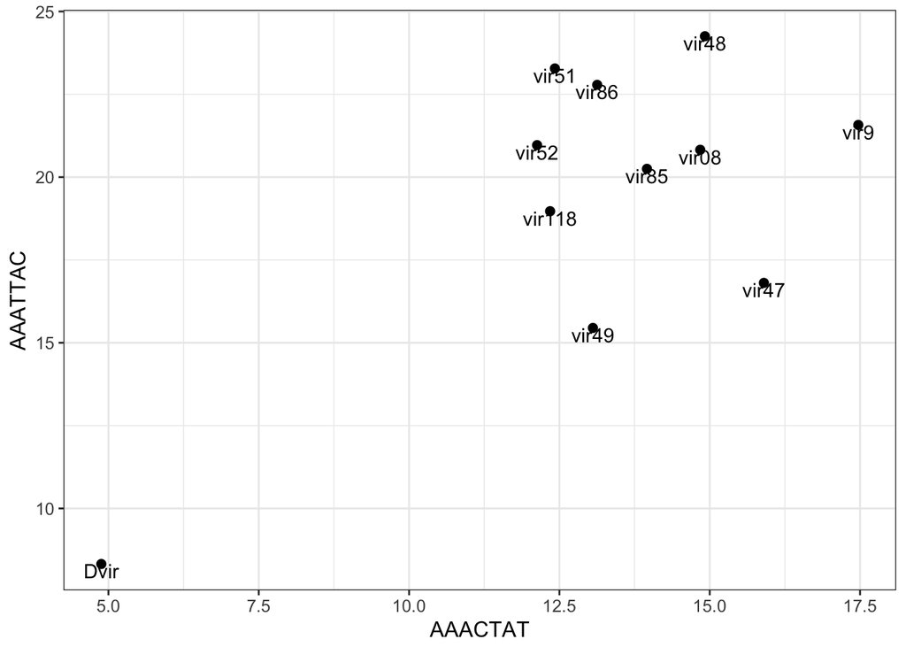

```r
# not a strong pattern in total bp

ggplot(plot_data, aes(x=AAATTAC, y=AAACTAT)) +
  geom_point(size=2) +
   theme_bw() +
  geom_text(aes(label=Row.names),hjust=0.5, vjust=1.0) +
  ylab("AAATTAC") +
  xlab("AAACTAT") +
  theme(text = element_text(size=12))
```

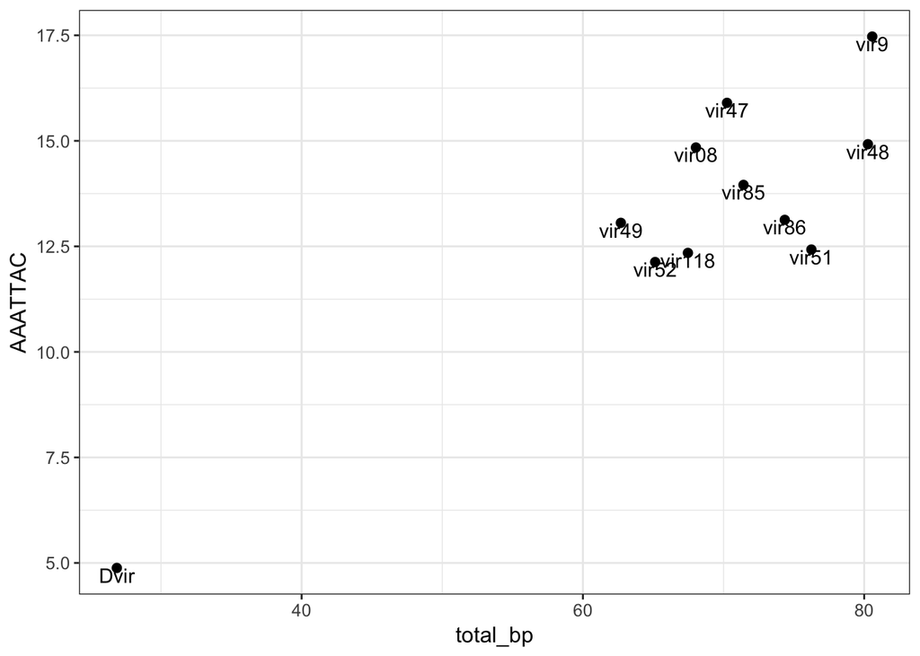

```r
ggplot(plot_data, aes(y=AAATTAC, x=total_bp)) +
  geom_point(size=2) +
   theme_bw() +
  geom_text(aes(label=Row.names),hjust=0.5, vjust=1.0) +
  ylab("AAATTAC") +
  xlab("total_bp") +
  theme(text = element_text(size=12))
```

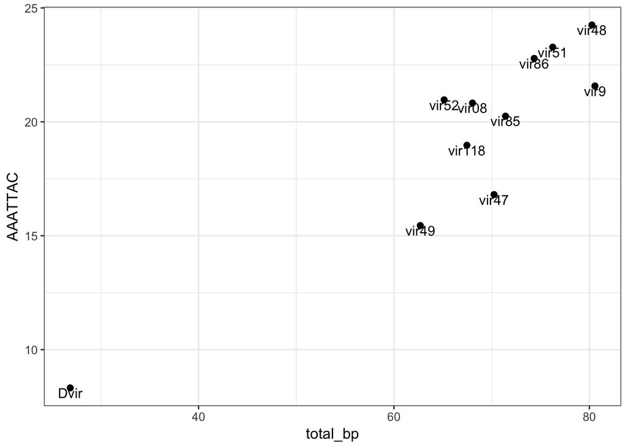

```r
#interesting pattern here

ggplot(plot_data, aes(y=AAACTAT, x=total_bp)) +
  geom_point(size=2) +
   theme_bw() +
  geom_text(aes(label=Row.names),hjust=0.5, vjust=1.0) +
  ylab("AAATTAC") +
  xlab("total_bp") +
  theme(text = element_text(size=12))
```

# 4) Now, in D. virilis, compare the amount of DINE-1 to the amount of pericentromeric AAACTAC (both expected to be high abundance on the 5th chromosome)

Note: DINE amount was calculated as the number of reads that mapped to our library divided by the average depth.

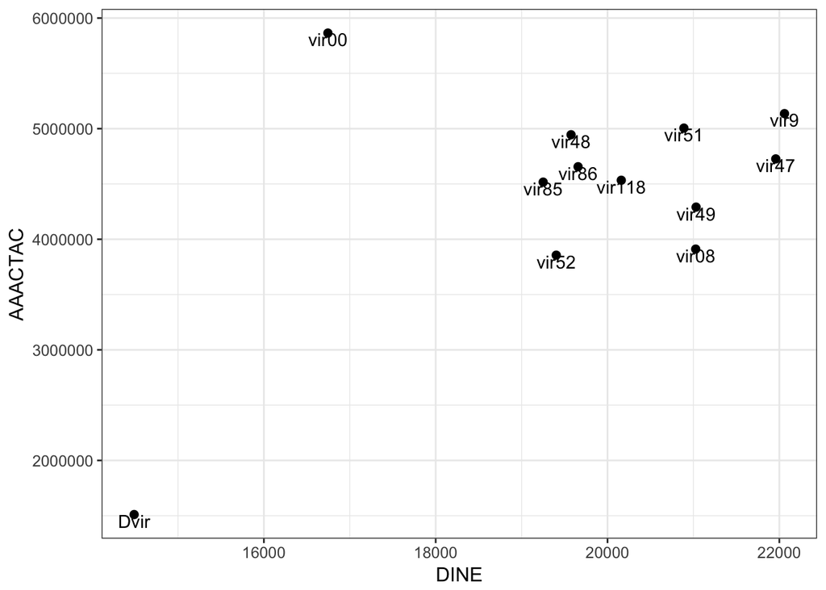

```r
options(scipen=999)
virilis_DINE <- read.csv ('/Users/jullienflynn/Documents/AndyLab/Heterochromatin/PacBio_scripts/Revised_scripts/D_virilis_satellites/Intra_inter_species_sequencing/ForR/virilis_DINE.csv')

data_virilis_DINE <- merge(virilis_DINE, data_virilis, by.x=1, by.y=1)

ggplot(data_virilis_DINE, aes(y=AAACTAC, x=DINE)) +
  geom_point(size=2) +
  geom_text(aes(label=Strain),hjust=0.5, vjust=1.0) +
  theme_bw() +
  theme(text = element_text(size=12))
```

```r
# notes: Males have more DINEs than females (comparison of genome strain), but still has lower DINEs than the others.
  # vir00 has the highest AAACTAC amount. It is an outlier in DINE amount. All other strains cluster very closely in DINE amount.
```

# 5) Now, let’s look closer at simple satellites in D. americana and their relationship to the presence of the X-4 fusion

Note: 100 means the fusion is at 100% frequency in that strain (i.e. is fixed) and 0 means the fusion is at 0% frequency in that strain (i.e. it is absent)

```r
data_americana <- subset(data_classified, species=="amer")

# get the mean of the abundant satellites
mean(data_americana$AAACTAC)
```

```
## [1] 1633691
```

```r
mean(data_americana$AAACAAC)
```

```
## [1] 250804.4
```

```r
americana_fus <- read.csv('/Users/jullienflynn/Documents/AndyLab/Heterochromatin/PacBio_scripts/Revised_scripts/D_virilis_satellites/Intra_inter_species_sequencing/ForR/americana_fusion_status.csv')
americana_fus$Sample <- as.vector(americana_fus$Sample)
sample.labels <- sapply(strsplit(americana_fus$Sample, "_"), '[', 1)
americana_fus$Sample <- sample.labels

data_amer_fus <- merge(data_americana, americana_fus, by.x=1, by.y=1)
data_amer_fus$Status <- as.factor(data_amer_fus$Status)

amer_names <- data_amer_fus$Row.names
rownames(data_amer_fus) <- amer_names
data_amer_fus[,kmers_of_interest]*7
```

```
##           AAACTAC   AAACTAT    AAATTAC AAACAAC
## amCI0515 11659768 446741.67   507.7953 1553168
## amCI0518 10437753 387720.16  1297.4537 1563964
## amCI0538 15143082 207251.66   501.6170 1818276
## amG96     8535324  29765.15  2131.3855 1647094
## amMK1012 12326032 235690.06   411.3088 1988137
## amML0738 12487254 181790.88 16438.1370 2188278
## amML975   9816893 169194.89   959.4196 1723763
## amSB     11080586 244707.45   255.4430 1562367
```

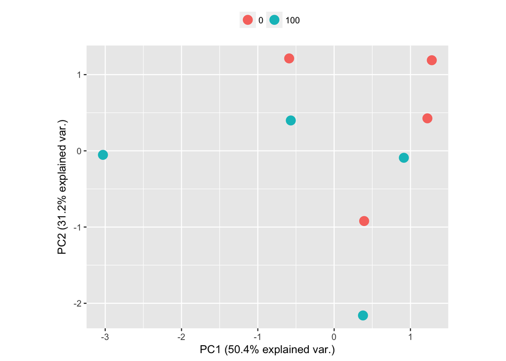

```r
# note the inbred genome strain also has the lowest amount, G96.

# Let's do PCAs.

pca.data <- prcomp(data_amer_fus[, kmers_of_interest], scale.=T)
g <- ggbiplot(pca.data, obs.scale = 1, var.scale = 1, groups = data_amer_fus$Status, var.axes = F, alpha=0.8)
g <- g + scale_color_discrete(name='') +
  geom_point(aes(colour=data_amer_fus$Status ), size=4)
g <- g + theme(legend.direction='horizontal', legend.position='top')
print(g)
```

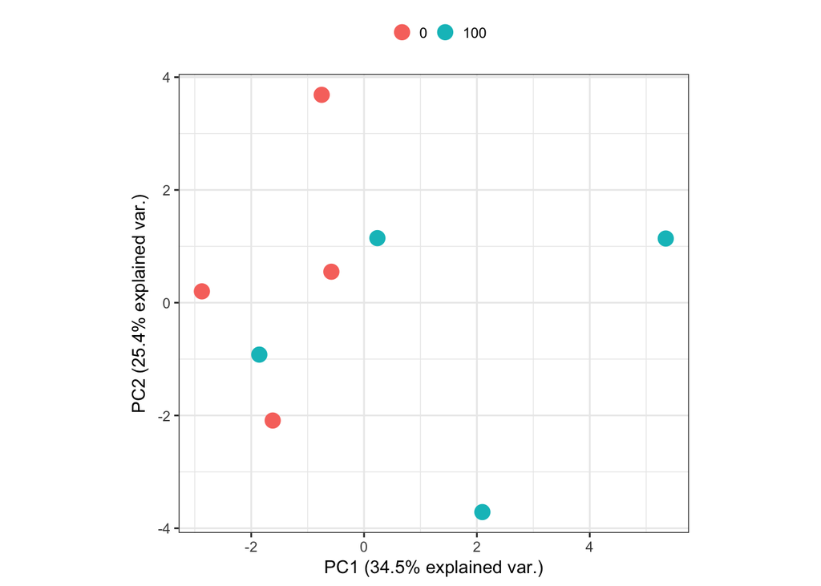

```r
# now using all abundant satellites.

pca.data <- prcomp(data_amer_fus[, 3:22], scale.=T)
g <- ggbiplot(pca.data, obs.scale = 1, var.scale = 1, groups = data_amer_fus$Status, var.axes = F, alpha=0.8) + theme_bw()
g <- g + scale_color_discrete(name='') +
  geom_point(aes(colour=data_amer_fus$Status ), size=4)
g <- g + theme(legend.direction='horizontal', legend.position='top')
print(g)
```

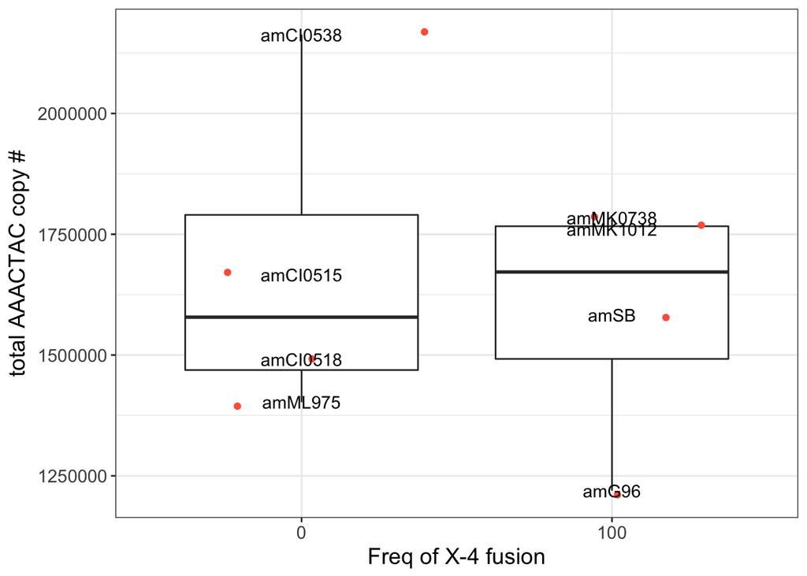

```r
# look at the pericentromeric and centromeric satellite for a comparison.

plot_data <- data_amer_fus[, c("Row.names","species", "Status", "AAACTAC", "AAACAAC")]

#fix a typo you made in the sample names

plot_data$Row.names[6] <- "amMK0738"


ggplot(data = plot_data, aes(x = Status, y = AAACTAC)) +
  geom_boxplot() +
  geom_jitter(color="tomato") +
  geom_text(aes(label=Row.names)) +
  theme_bw() +
  xlab("Freq of X-4 fusion") +
  ylab("total AAACTAC copy #") +
  theme(text = element_text(size=14))
```

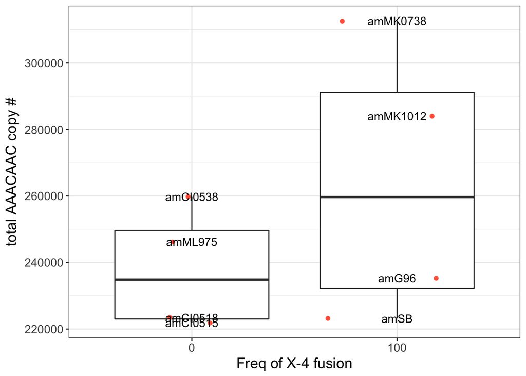

```r
ggplot(data = plot_data, aes(x = Status, y = AAACAAC)) +
  geom_boxplot() +
  geom_jitter(color="tomato") +
  geom_text(aes(label=Row.names)) +
  theme_bw() +
  xlab("Freq of X-4 fusion") +
  ylab("total AAACAAC copy #") +
  theme(text = element_text(size=14))
```

# 6) Let’s look at the polymorphism in other satellites than the most abundant ones.

The PCA had a lot more separation when looking at the top 20 satellites than when only looking at the top 4. That means there must be some interesting variation.

Need to check if these are satellites I mention in the manuscript.

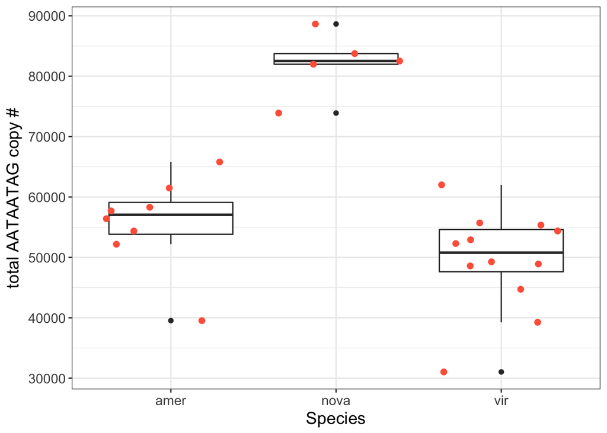

```r
ggplot(data = data_classified, aes(x = species, y = AATAATAG)) +
  geom_boxplot() +
  geom_jitter(color="tomato", size = 2) +
  theme_bw() +
  xlab("Species") +
  ylab("total AATAATAG copy #") +
  theme(text = element_text(size=14))
```

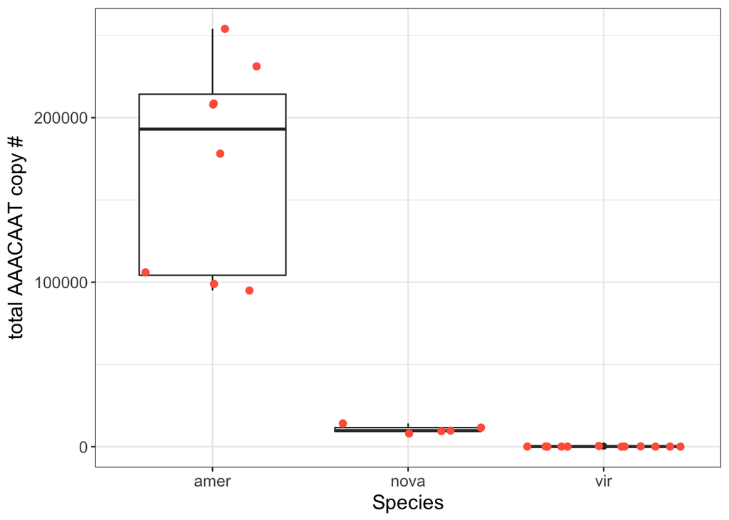

```r
ggplot(data = data_classified, aes(x = species, y = AAACAAT)) +
  geom_boxplot() +
  geom_jitter(color="tomato", size = 2) +
  theme_bw() +
  xlab("Species") +
  ylab("total AAACAAT copy #") +
  theme(text = element_text(size=14))
```

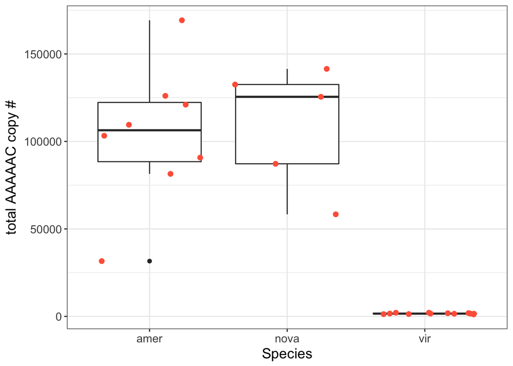

```r
ggplot(data = data_classified, aes(x = species, y = AAAAAC)) +
  geom_boxplot() +
  geom_jitter(color="tomato", size = 2) +
  theme_bw() +
  xlab("Species") +
  ylab("total AAAAAC copy #") +
  theme(text = element_text(size=14))
```

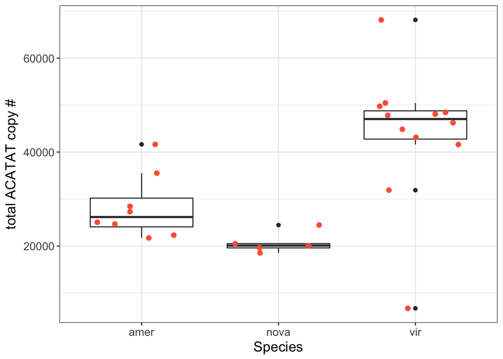

```r
ggplot(data = data_classified, aes(x = species, y = ACATAT)) +
  geom_boxplot() +
  geom_jitter(color="tomato", size = 2) +
  theme_bw() +
  xlab("Species") +
  ylab("total ACATAT copy #") +
  theme(text = element_text(size=14))
```

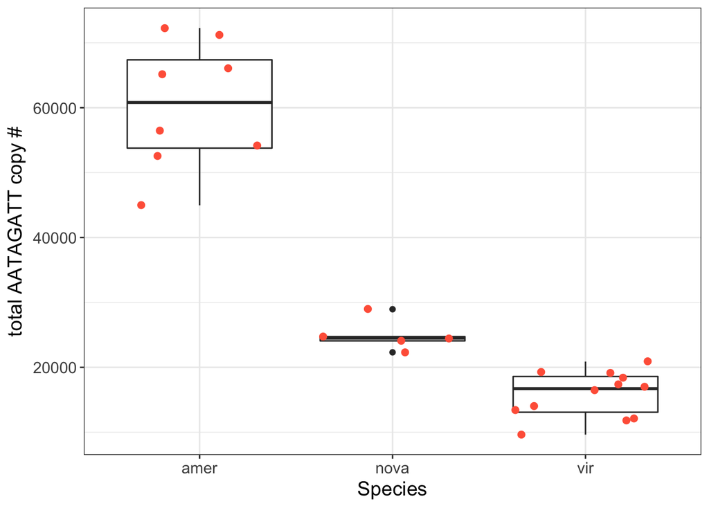

```r
ggplot(data = data_classified, aes(x = species, y = AATAGATT)) +
  geom_boxplot() +
  geom_jitter(color="tomato", size = 2) +
  theme_bw() +
  xlab("Species") +
  ylab("total AATAGATT copy #") +
  theme(text = element_text(size=14))
```

# 7) Examining the sequence identity of the satellites in the different strains in the virilis group.

I ran NCRF on the Illumina reads and got an estimate of the divergence of each read against the satellite consensus.  
To get the average:  
`cat vir51_GTGAAA_R1.AAATTAC.ncrf10.summary | cut -f 9 | sed '1d' | cut -f 1 -d "%" | awk '{sum += $1} END {print sum/NR}'`

To get the histogram:  
`cat vir51_GTGAAA_R1.AAATTAC.ncrf10.summary | cut -f 9 | sed '1d' | cut -f 1 -d "%" > vir51.AAATTAC.div`

*Averages for AAATTAC*:  
vir 51: 99.2845  
vir 47: 99.1281  
vir 08: 99.1521  
vir 85: 99.0458  
vir 48: 99.016  
vir 49: 99.0608  
vir 86: 99.1352  
vir 00: 99.0311  
vir 118: 99.0857  
vir87f: 99.3137  
vir9: 99.0107  
vir52: 99.1317  
vir87m: 98.8845

*Averages for AAACTAT*:  
vir 51: 99.4189  
vir 48: 99.214  
vir 86: 99.3357  
vir 00: 99.2537  
vir 08: 99.3284  
vir 85: 99.2455  
vir 9: 99.1911  
vir 47: 99.3142  
vir 52: 99.304  
vir 118: 99.2691  
vir 49: 99.261  
vir87f: 99.4603  
vir 87m: 99.0681

Now, the sequence identity of the pericentromeric satellite AAACTAC.

**D. virilis**:  
vir 51: 98.4117  
vir 00: 98.3733  
vir 85: 98.282  
vit 118: 98.3237  
vir 86: 98.44  
vir 08: 98.4376  
vir 49: 98.3455  
vir 52: 98.3606  
vir 47: 98.4035  
Gvir87f: 98.5956  
Gvir87m: 97.9103  
vir 48: 98.3038  
vir 9: 98.3405

**D. novamexicana**:  
nova8: 98.6006  
nova12: 98.2135  
nova4: 98.5409  
nova13: 98.4448  
Gnova14: 98.4718

**D. americana**:  
amCI0538: 98.3903  
amCI0515: 98.482  
amMK1012: 98.5945  
amSB: 98.3237  
amCI0518: 98.3606  
amML975: 98.5578  
amG96: 98.3568  
amML0738: 98.4075

Now, the sequence identity in the centromeric satellite *AAACAAC*:

**D. novamexicana**:  
nova12: 97.1442  
nova4: 97.4311  
nova8: 97.4563  
nova13: 97.3354  
Gnova14: 97.362

**D. americana**:  
amCI0518: 97.3998  
amCI0515: 97.5062  
amMK1012: 97.629  
amML0738: 97.4118  
amSB: 97.3541  
amCI0538: 97.4072  
amML975: 97.4914  
amG96: 97.3696